# Exploring Heterogeneity (Sales Taxes)

John Bonney

December 13, 2018

## Tasks

I think that we could explore heterogeneity in covariates a little more and try to see if some of this heterogeneity can explain the different patters that we observe between our treatment and control groups.

1. It would be nice to plot the distribution of reforms (separately for increases and decreases) over time. Are these reforms all happening at the same time or at different times? You can plot this at the quarter level.
2. You already made a map showing the different groups. That is great. Include it in the document with the distribution of timing of reform. It might be nice to also have a breakdown of how many counties per state are included in the two groups.
   - Make table of columns: state name, # ever increase, # ever decrease, total counties
3. The regressions like Manasi’s paper may help. Do counties in the three groups differ in terms of their demographics, median income, rural/urban status
   - Fix time-varying characteristics to one point in time (Jan 2008)
4. It might be good to look at the graphs together one more time today. But If I remember correctly, the main concern was that seasonality was stronger in the increase group than other counties. Another thing that we could do to deal with this is to “open the data” and try to identify which goods show the most seasonality then drop them from the sample. It might be informative for us to do anyway (identify which types of good tend to show more seasonality).
   - Take full-sample (all products, counties), estimate the season fixed effect at product-level – then look at difference between min and max (within the four seasons) of the coefficients for each products – that could give us a measure of seasonality

## Distribution of Reforms

### Distribution over time

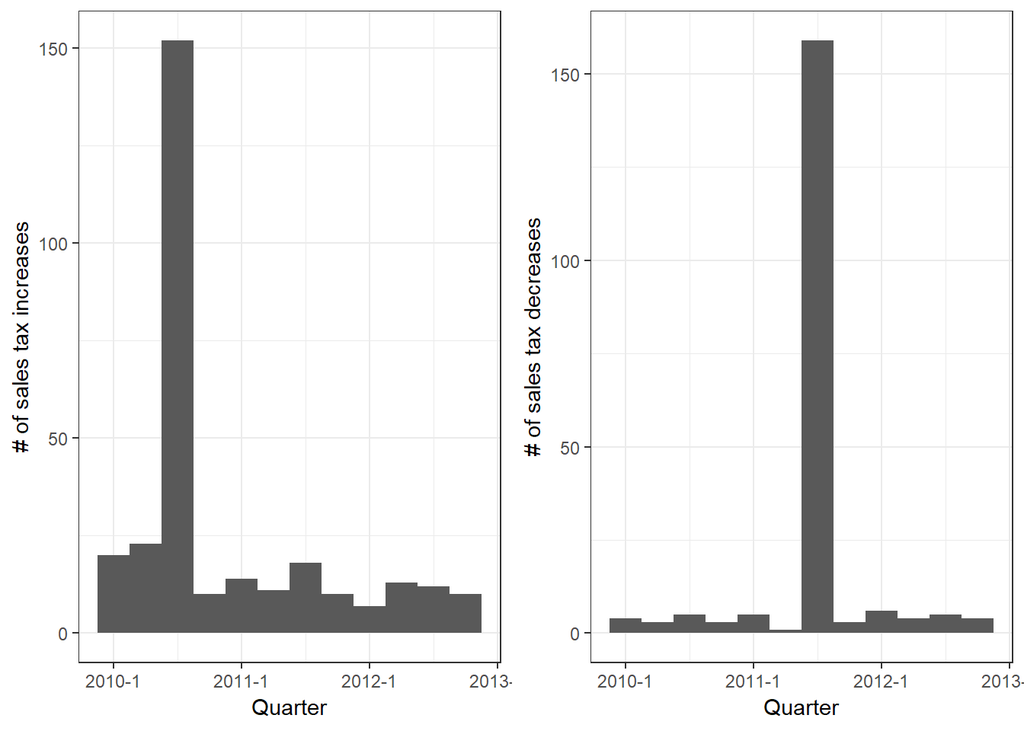

As we can see, most of the increases are concentrated in 2010 Q3, and most of the decreases are concentrated in 2011 Q3. What is driving these large spikes?

```r
# Which states are driving the spike in increases?
with(reforms[change == "Increase" & year_qtr == "2010 Q3"],
     table(state_name, change))
```

```
##                 change
## state_name       Increase
##   Illinois              4
##   Kansas              105
##   Louisiana             1
##   Missouri              3
##   New Mexico           33
##   North Carolina        4
##   Ohio                  1
##   Washington            1
```

```r
# Which states are driving the spike in decreases?
with(reforms[change == "Decrease" & year_qtr == "2011 Q3"],
     table(state_name, change))
```

```
##                 change
## state_name       Decrease
##   California           58
##   North Carolina      100
##   Ohio                  1
```

These spikes in tax decreases and tax increases were specifically driven by four reforms:

- In July 2010, New Mexico **increased** its state sales tax by 0.125%, from 5% to 5.125% *(33 counties)*
- In July 2010, Kansas **increased** its state sales tax by 1.0%, from 5.3% to 6.3% *(105 counties)*
- In July 2011, North Carolina **decreased** its state sales tax by 1.0%, from 5.75% to 4.75% *(100 counties)*
- In July 2011, California **decreased** its state sales tax by 1.0%, from 8.25% to 7.25% *(58 counties)*

### Geographical distribution

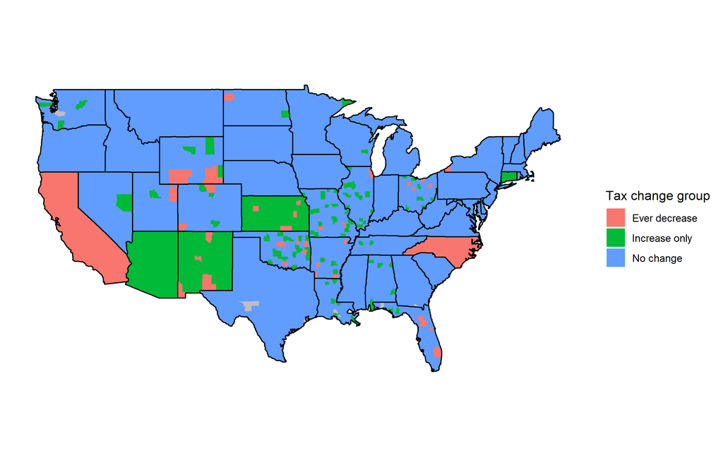

Tax Changes by County

The only state-wide tax change not captured in the previous analysis is Arizona’s June 2010 tax increase, which increased state sales tax by 1%, from 5.6% to 6.6%.

### Breakdown by state

Number of counties that increased/decreased sales taxes between 2010 and 2012 (by state)

| State | # ever increase | # ever decrease | Total |
| --- | --- | --- | --- |
| Alabama | 5 | 0 | 67 |
| Alaska | 0 | 0 | 29 |
| Arizona | 15 | 0 | 15 |
| Arkansas | 4 | 4 | 75 |
| California | 1 | 58 | 58 |
| Colorado | 3 | 2 | 64 |
| Connecticut | 8 | 0 | 8 |
| Delaware | 0 | 0 | 3 |
| Florida | 2 | 5 | 67 |
| Georgia | 0 | 0 | 159 |
| Hawaii | 0 | 0 | 5 |
| Idaho | 0 | 0 | 44 |
| Illinois | 16 | 1 | 102 |
| Indiana | 0 | 0 | 92 |
| Iowa | 0 | 0 | 99 |
| Kansas | 105 | 5 | 105 |
| Kentucky | 0 | 0 | 120 |
| Louisiana | 6 | 0 | 64 |
| Maine | 0 | 0 | 16 |
| Maryland | 0 | 0 | 24 |
| Massachusetts | 0 | 0 | 14 |
| Michigan | 0 | 0 | 83 |
| Minnesota | 1 | 0 | 87 |
| Mississippi | 0 | 0 | 82 |
| Missouri | 21 | 2 | 115 |
| Montana | 0 | 0 | 56 |
| Nebraska | 0 | 0 | 93 |
| Nevada | 1 | 0 | 17 |
| New Hampshire | 0 | 0 | 10 |
| New Jersey | 0 | 0 | 21 |
| New Mexico | 33 | 4 | 33 |
| New York | 0 | 1 | 62 |
| North Carolina | 15 | 100 | 100 |
| North Dakota | 1 | 1 | 53 |
| Ohio | 12 | 4 | 88 |
| Oklahoma | 17 | 6 | 77 |
| Oregon | 0 | 0 | 36 |
| Pennsylvania | 0 | 0 | 67 |
| Rhode Island | 0 | 0 | 5 |
| South Carolina | 1 | 0 | 46 |
| South Dakota | 0 | 0 | 66 |
| Tennessee | 2 | 0 | 95 |
| Texas | 0 | 0 | 254 |
| Utah | 1 | 1 | 29 |
| Vermont | 0 | 0 | 14 |
| Virginia | 0 | 0 | 133 |
| Washington | 4 | 0 | 39 |
| West Virginia | 0 | 0 | 55 |
| Wisconsin | 1 | 0 | 72 |
| Wyoming | 5 | 4 | 23 |

## Predictive characteristics

We have some variables obtained from Zillow.com and IPUMS National Historical Geographic Information System (NHGIS) in addition to the Quarterly Census of Employment and Wages (QCEW) and the Local Area Unemployment Statistics, both from the Bureau of Labor Statistics. We can use these data (restricted to information determined prior to the tax change) to see which county characteristics “predict” sales tax changes:

| Variable | Source | Description |
| --- | --- | --- |
| `SizeRank` | Zillow | Rank of county size (by pop.) (Jan. 2006) |
| `median_home_price` | Zillow | Median home price (Jan. 2006) |
| `pop` | NHGIS | County pop. (2000) |
| `pop_urban` | NHGIS | Pop. living in urban areas (2000) |
| `pop_black` | NHGIS | Pop. identifying as black (2000) |
| `pop_over_65` | NHGIS | Pop. over age 65 (2000) |
| `pop_under_25` | NHGIS | Pop. under age 25 (2000) |
| `pct_pop_no_college` | NHGIS | Pct. pop. without a college degree (2000) |
| `pct_pop_bachelors` | NHGIS | Pct. pop. with bachelor’s degree or higher (2000) |
| `median_income` | NHGIS | Median income (2000) |
| `total_housing` | NHGIS | Total housing units (2000) |
| `owner_occupied_housing` | NHGIS | Total owner-occupied housing units (2000) |
| `annual_avg_emplvl`[^1] | QCEW | Establishment employment level (2006) |
| `retail_employment` | QCEW | Retail industry employment (2006) |
| `total_establishments` | QCEW | Total number of establishments (2006) |
| `retail_establishments` | QCEW | Total number of retail establishments (2006) |
| `food_and_drugstores_empshare` | QCEW | Fraction of employed workers working in food and drugstores (2006) |
| `total_mean_wage` | QCEW | Mean wage (2006) |
| `retail_mean_wage` | QCEW | Mean wage in retail industry (2006) |
| `laborforce` | LAUS | Labor force size (2006) |
| `employed`[^2] | LAUS | Total employment level (2006) |
| `unemployed` | LAUS | Unemployed level (2006) |
| `unemp_rate` | LAUS | Unemployment rate (2006) |

In addition to these variables, I have industry employment shares for a number of different industries from the QCEW. I adapted many of the vairables in this table to be in percentage or log terms for comparability across counties.

## Product-specific seasonality

The goal here is to identify which goods exhibit the most seasonality over time. However, this must be done on the server due to the size of the dataset. On the server, I estimate the following model on the product ($p$)-store ($s$)-quarter ($q$)-year ($y$) level:[^3]
$$y_{psqy} = \alpha_{qp} + \gamma_ptime_{t(q,y)} + \epsilon_{psqy},$$
where
$$y_{psqy} = \textrm{ln}\left(\frac{sales_{psqy}}{sales_{psQ_12008}}\right),$$
$\gamma_p$ is a product-specific linear time effect, and $\alpha_{qp}$ is a product-quarter fixed effect. I then calculate a seasonality range for each product,
$$SR_p = \max_{q}(\alpha_{qp})-\min_{q}(\alpha_{qp}).$$
$SR_p$ is then essentially the product-specific ratio of normalized log sales of the season with the highest average sales to the season with the lowest average sales.[^4] We use it primarily to compare seasonality across goods.

We can use these resulting $SR_p$ indicators to examine the distribution of seasonality within the 265 best-selling products in our balanced panel.

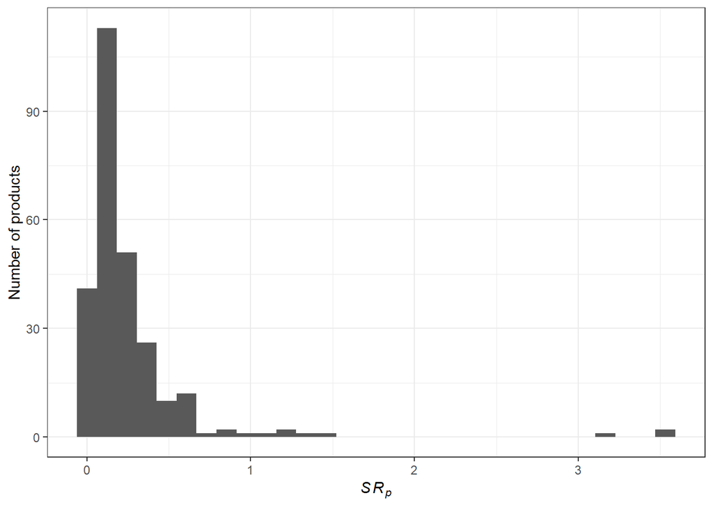

Distribution of seasonality range across products

Most products appear to exhibit some sort of seasonality. However, there are clearly some outliers. Which products are these?

```
##                               module_description seasonality_range
##  1:                      CANDY-CHOCOLATE-SPECIAL         3.5433299
##  2:                FAN AND CEILING FAN APPLIANCE         3.5084183
##  3: SUNTAN PREPARATIONS - SUNSCREENS & SUNBLOCKS         3.1146498
##  4:                                     CHARCOAL         1.5063585
##  5:                     VIDEO AND COMPUTER GAMES         1.3502929
##  6:        PERSONAL PLANNERS BINDERS AND FOLDERS         1.2103445
##  7:                           FRESH STRAWBERRIES         1.1727359
##  8:                                          ICE         1.1369999
##  9:                   VIDEO PRODUCTS PRERECORDED         0.9453739
## 10:                    FROZEN MEAT - GROUND BEEF         0.8400961
```

Not surprisingly, these are goods one would expect to be correlated with seasons, due to:

- Holidays (chocolate, video games)
- Summer (fans, sunscreens & sunblocks, charcoal, ice)
- Back-to-school (binders & folders)
- Seasonal production (fresh strawberries)
- Seasonal transportation costs (ground beef)
[^1]: Note that there are two measures of employment, one from the QCEW (`annual_avg_emplvl`) and one from the LAUS (`employed`). This is because the QCEW estimates employment levels using establishment data, but the BLS adjusts these measures using commutation factors calculated from the Census Bureau’s American Community Survey (ACS). For more information, see the BLS [estimation methodology](https://www.bls.gov/lau/laumthd.htm).
[^2]: See footnote 1.
[^3]: For computational purposes, I instead residualize out the linear time trend to obtain $\tilde{y}_{psqy} = y_{psqy} - \gamma_ptime_{t(q,y)}$ and then take the mean of $\tilde{y}_{psqy}$ over all stores $s$ and years $y$ for each product-quarter pair to obtain $\alpha_{qp}.$ This is functionally equivalent to what the estimated product-quarter fixed effects would be (without an intercept).
[^4]: Consider this measure restricted to only one store $s$ in just one year, $y=2008.$ See that
    $$\alpha_{qp} = \ln{\frac{sales_{pq}}{sales_{pQ_1}}}.$$
    Then we have
    $$\begin{aligned}
    SR_p &= \max_{q}(\alpha_{qp})-\min_{q}(\alpha_{qp}) \\
    &= \max_{q}\biggl(\ln{\frac{sales_{pq}}{sales_{pQ_1}}}\biggr) - \min_{q}\biggl(\ln{\frac{sales_{pq}}{sales_{pQ_1}}}\biggr) \\
    &= \ln{\left(\frac{\max_q{(sales_{pq}/sales_{pQ_1}})}{\min_q{(sales_{pq}/sales_{pQ_1}})}\right)} \\
    &= \ln{\left(\frac{\max_q{sales_{pq}}}{\min_q{sales_{pq}}}\right)}
    \end{aligned}$$
    We can extend this to an arbitrary number of stores and years (assuming a balanced panel for each product and no linear time trend). Let $\bar{q}$ denote the quarter that maximizes $\alpha_{qp},$ let $\underline{q}$ denote the quarter that minimizes $\alpha_{qp},$ and let $N_{s,y}$ denote the number of store-years in the data. It is simple to show that
    $$SR_p = \frac{1}{N_{s,y}}\sum_{s,y}\ln\biggl(\frac{sales_{ps\bar{q}y}}{sales_{ps\underline{q}y}}\biggr),$$
    which is clearly the average over all store-years of the log ratio of sales in $\bar{q}$ to sales in $\underline{q}.$